# Parent-Offspring Conflict and Bargaining Behaviors in Adolescence and Young Adulthood among Chon Chuuk (Chuukese) Micronesians

Kristen L. Syme (Department of Experimental and Applied Psychology, Vrije Universiteit Amsterdam) , Edward H. Hagen (Department of Anthropology, Washington State University)  
May 11, 2019

# Introduction

Chon Chuuk (‘People of the Mountain’), also called the Chuukese, are an Austronesian-speaking population of approximately 50,000 people native to the Caroline Islands in Chuuk State, Federated States of Micronesia. Of the 290 islands in Chuuk State, 40 are inhabited. Chuuk Lagoon, the population center, consists of high volcanic islands surrounded by a scattering of coral atolls stretching over thousands of square kilometers of ocean. There are several mutually intelligible regional dialects of the Chuukese language, and there are cultural variances by island region. Traditionally, Chon Chuuk obtained their diet through fishing, gathering marine and plant resources, and gardening (Gladwin and Sarason 1953). As more islanders entered the wage economy in the mid-twentieth century, however, imported foods became a source of nutrition and status (L. B. Marshall and Marshall 1980; Hezel 1987). Today, most families living in Chuuk Lagoon rely on cash-bought imported foods supplemented by local subsistence. The populations on the outer atolls still rely heavily on fishing and local agriculture but supplement their diet with imported foods.

Chon Chuuk, like many other colonized indigenous populations, have a high male-biased youth suicide rate that reached epidemic proportions in the early 1970’s (Hezel 1987). At the peak of the suicide epidemic during the 1980’s, there were almost 40 suicides per 100,000 and over half of all suicides were between the ages of 15-24 (Hezel 1989). By comparison, there were around 11 suicides per 100,000 in the United States during that same period (Lindsay Lee and Ortiz-Ospina 2019). Colonial interventionism and the monetization of the economy led to fundamental changes in family and village-level organization including the nuclearization of the family and the loss of traditional men’s meeting houses (uut) where adolescent male socialization occurred (Rubinstein 1992; Hezel 1987). Hezel has described Chuukese suicides as a tightly patterned response to conflict with elder family members, and a thorough collection of documented cases shows that conflicts between parents and children is the most frequent triggering event (Hezel 1984, 1989; Rubinstein 1995).

Although Hezel and Rubinstein have collected considerable data on cases of conflicts that lead to suicide, there has been less focus on the broad array of child responses to conflicts with parents that are far less devastating, yet far more common, than suicide. Nevertheless, understanding these common but less severe child responses could potentially illuminate the social dynamics that put some children at risk of a suicide attempt. One study that did examine 40 cases of interpersonal conflicts in Chon Chuuk adolescents found that the high rate of social problems among youths in this region resulted from intergenerational conflict within the family (Lowe 2003). Specifically, incongruence between the status-building activities of young men and women and the needs of the family was a leading source of stress that could lead to ruptures in the parent-child relationship (Lowe 2003).

A typical response to such conflicts is for the child to run off, avoiding their family for a period ranging from a few minutes to a few days or weeks depending on the intensity of the child’s hurt or anger. Such responses are seen as expressions of *Amwunumwun*, a spectrum of behavioral strategies involving withdrawal and self-abasement whereby an individual distances herself from others as a means of releasing strong negative emotions in a societal context where social norms dictate against directly confronting elders and other social superiors (Hezel 1987). Amwunumwun behaviors vary in severity from transient withdrawal to running away to suicide threats and even suicide death.

The present study builds off this previous ethnographic work on suicide, social conflict, and psychosocial stress among Chon Chuuk, examining conflicts between parents and children during the adolescent and young adult period and the spectrum of behavioral strategies offspring use to resolve conflicts. Social conflict is a widespread precursor to suicidal behavior (Syme, Garfield, and Hagen 2016; Syme and Hagen 2019), yet there is little research that explores what separates the few conflicts the lead to suicidality from the vast majority that do not.

# Evolutionary theory of parent-offspring conflict

Parent-offspring conflict (POC) theory proposes that, in any sexually reproducing species, the genetic asymmetries in relatedness between parents and offspring produce asymmetrical interests in resource allocation, and “conflict is seen to be an expected feature of such relations” (Trivers 1974). A parent shares half its genes with all its offspring, whereas each offspring shares 100% of its genes with itself, half with its full siblings, and one quarter with its half siblings. Hence, the distribution of resources and other investment that maximizes a parent’s biological fitness does not necessarily maximize the fitness of each offspring. Conversely, the investment that would maximize the fitness of a particular offspring would not necessarily maximize the fitness of its parent nor of its siblings. In a recent theoretical treatment, this conflict is conceptualized as intragenomic conflict between supply genes expressed in the parent and demand genes expressed in offspring, and results show that lower levels of monogamy increase POC (Bossan, Hammerstein, and Koehncke 2013).

According to this theory, offspring are expected to bid for more resources than parents are willing to provide; therefore, offspring might try to deceive parents into providing more benefits than they genuinely need. Similarly, parents might try to manipulate individual offspring into maximizing the parents inclusive fitness at a cost to that offspring (Trivers 1974). Sibling conflict is a concomitant of POC because, like parents and offspring, each sibling is 100% related to itself but only related 50% to its full siblings and 25% to its half siblings.

In humans and other mammals, weaning conflict might be one example of POC (Trivers 1974). Whereas POC in many species is limited to periods of high parental provisioning in early life, humans have not only a long period of juvenile dependency relative to other mammals (Kaplan et al. 2000), but parents across all human societies invest in offspring into adulthood, including arranging marriages and assisting in the care of grandchildren (Hawkes et al. 1998; Sear, Mace, and McGregor 2000; Sear and Mace 2008). Thus, as Trivers highlights (Trivers 1974), POC can manifest into the adult reproductive period of offspring.

Arrangement of marriages by parents is widespread across cultures and is a source of disagreement between parents and offspring (Apostolou 2007). Offspring are predicted to value cues of genetic quality (e.g., physical attractiveness) more than their parents who are predicted to place a higher value on cues of in-group cooperation (e.g., shared cultural and religious background)–a hypothesis that is supported by a serious of studies (Buunk, Park, and Dubbs 2008; Apostolou 2015; Dubbs and Buunk 2010; Buunk and Solano 2010; Van den Berg et al. 2013; Dubbs, Buunk, and Taniguchi 2013). Other research indicates that parents and offspring might further disagree on the optimal degree of relatedness of a potential spouse. Analyzing Yanomamo data, Chagnon et al. (2017) found that although offspring who married close genetic relatives suffered inbreeding depression, these marriages yielded reproductive benefits for their parents, who had greater numbers of overall grandchildren.

It is important to distinguish conflicts of interest between parents and offspring from differences in knowledge (Trivers 1974). So far, our discussion has focused on conflicts of interest e.g., offspring benefiting from more investment than their parents are willing to provide. But some “conflicts” in the folk sense might not be due to conflicts of interest but instead be due to differences in knowledge. Parents often have knowledge about the physical and social environment that offspring have not yet acquired. Despite the child’s objections, for instance, a parent might insist that she learn to read because the parent knows that reading will be valuable in adulthood. Similarly, parents might be better judges of some aspects of an offspring’s potential mate based on their greater experience with mating.

# Parent-offspring cooperation

In all species, parent and offspring “cooperate” to ensure the offspring’s successful development and survival. Because humans have such a long juvenile period, and typically live with their parents for many years, there is great scope for extensive cooperative interactions. Unlike most other species, human offspring provide alloparental care, for example, which has been shown to have a positive impact on health and survivorship of their siblings (Helfrecht and Meehan 2016; Kramer 2005; Breeding 2009; Sear et al. 2002; Sear and Mace 2008). Older sisters, in particular, often play an active role in caring for younger siblings, and in some societies, young girls begin acquiring childcare skills through sibling investment by ages 5 and 6 (Weisner et al. 1977; Weisner 1987; Zukow-Goldring 2002; LeVine et al. 1996). Human offspring are therefore both consumers and producers, and children in some ecological contexts begin supplementing their diets and contributing resources to the household through foraging and hunting small game as early as ages 5-7 (Bird and Bird 2017; Tucker and Young 2017). Chon Chuuk children are no different and begin assisting in childcare and learning subsistence techniques well before puberty (Fischer 1950; Gladwin and Sarason 1953).

Nevertheless, where there is cooperation between organisms with divergent interests, there is also a potential for cheating and exploitation. Therefore, POC in humans can entail conflicts over the time and resources parents allocate to offspring, as well as the time and resources offspring allocate to the family, e.g., as ‘helpers at the nest’ (Turke 1988).

# Conflicts in adolescents and young adults in Chuuk

Bogin divides human development into five stages: 1) infancy (early childhood), 2) childhood (post-weaning), 3) juvenility (a period of feeding independence preceding reproductive maturity), 4) adolescence (the onset of sexual maturity accompanied by rapid growth spurts), and 5) adulthood. POC can occur during any stage of human development as long as parents and offspring maintain a cooperative relationship. In the present study, we focus on POC during adolescence and early adulthood. These stages are of interest because they are associated with heightened risk for suicidal behavior, substance abuse, and physical aggression among Chon Chuuk (Rubinstein 1992; Hezel 1987, 1989; M. Marshall 1979).

Adolescence is marked by physiological changes associated with sexual maturation such as ovulation and breast development in females and an increase in testicular size in males. The adolescent transition is also associated with cognitive changes including enhancements in abstract thinking, thought processing speed, and perspective taking (Bogin et al. 2018; Smetana and Villalobos 2009; Yurgelun-Todd 2007). Adolescents must navigate new social challenges including short or long-term mating relationships, sexual competition and status seeking, and cooperative economic activity. Males, in particular, might also form relationships with same-sex older adults for apprenticeship training in subsistence, magico-religious, economic, and political tasks and roles.

According to early ethnographies, Chon Chuuk regard adolescence as a transitional period between childhood and adulthood. Young males and females were generally not expected to be as economically productive as adults and induction into adult roles was gradual (Gladwin and Sarason 1953). The ethnographic literature does not describe any event that uniquely marked men’s and women’s entrance into adulthood. Although women tended to marry by age 20 and young men shortly after 20, first marriages were often unstable in the past (Ward Hunt Goodenough and Skoggard 1999; Caughey 1977). Ward H. Goodenough (1949), and later M. Marshall (1979), reported that many men’s skills and esoteric lore were not learned until middle age, and young men were often dismissed as too preoccupied with alcohol and women to hold authority. Many young men occupied a more or less adolescent position until their late twenties or early thirties.

Before World War II, a Chon Chuuk boy upon reaching puberty moved out of the domestic house (imw) and into the lineage men’s house (uut) where the unmarried men of the lineage resided in accordance with proscriptions against opposite sex siblings sleeping under the same roof (Ward H. Goodenough 1974; Gladwin and Sarason 1953). The uut served as the canoe and meeting house for the lineage and was the site where older males trained younger males in folklore and the art of warfare (Ward Hunt Goodenough 1951). Adolescent and unmarried males took part in lineage-level subsistence activities such as fishing and maintaining corporately held gardens (Hezel 1987; Rubinstein 1992). Adolescent females, on the other hand, continued to live in the imw with the women of the lineage and their husbands, assisting in childcare, subsistence, and other household activities. But, the Second World War drastically disrupted village life across Micronesia, and men’s meeting houses fell into disuse and altered young men’s socialization.

In Chuuk, POC often arises over conflicts concerning offspring status-building activities. For young men, activities that increase status among one’s peers, such as drinking, fighting, and risky late-night sexual rendezvous, decrease the status of one’s family within the community. The status-building activities of young women often take place at church and tend to be more socially acceptable such as bringing food and drink to share at meetings (Weisner and Lowe 2005). In either case, however, hanging out with friends decreases time invested in assisting the family with its needs, and money spent on food, beverages, or alcohol is money not spent on household needs (Lowe 2003). The evidence suggests that these conflicts are heightened in periurban regions of Chuuk where families are dependent on youth to contribute to household subsistence, but the supplementation of the diet with store-bought items frees up some time for adolescents and young adults to spend in unsupervised peer activities (Hezel 1987; Rubinstein 1987). Unlike the urban youth who contribute little to household subsistence and rural youth who have little time to spend in unsupervised peer activities, periurban youth may feel pulled in both directions. Parents and offspring each stand to benefit from the offspring’s investment in the household, but conflict over the optimal amount of investment offspring should commit. Likewise, parents stand to benefit if offspring status-building enhances offspring fitness but conflict over the time allocation, level of risk, and social acceptability of these activities.

# Conflict resolution strategies

One strategy for resolving conflicts in one’s favor is to impose costs through the threat or use of violence. Although much evolutionary literature focuses on the use of physical violence between competitors who have opposing interests in a zero-sum game (e.g., competitors over mates or resources), physical violence also occurs between those who have shared interests. Among Tsimane forager-horticulturalists, for example, men use physical violence to stifle wives’ protests against the diversion of household resources to the husbands’ paramours (Stieglitz et al. 2012, 2011), and in many societies parents use corporal punishment to deter undesirable behaviors in children such as refusing to share or cooperate with siblings (Ember and Ember 2005; Levinson 1981).

Sell et al. and others have found that upper body strength in males positively predicts proneness to physical aggression and anger in Western and non-Western populations [Sell (2005); Sell, Tooby, and Cosmides (2009); Sell, Hone, and Pound (2012); Hess et al. (2010); Archer and Thanzami (2007). The strategic use of physical aggression, therefore, is only available to those individuals who are formidable enough to pose a threat to their opponents, because the use of physical force by a weaker party invites harm. It is not surprising then that the direction of physical force moves from males to females, parents to small children, and groups to individuals. Thus, an individual who is able to form a coalition is also at an advantage. For instance, coalitions can form among groups of close genetic male kin who share an interest in each other’s fitness (Macfarlan et al. 2018; Chagnon 1979). Another route to power is resource holding potential (RHP)–the ability of an individual to offer or withhold resources under her control (Sosis, Feldstein, and Hill 1998; J. M. Smith and Parker 1976; Parker 1974). We can measure RHP in terms of wealth, status, physical attractiveness, among other possibilities. Resources relevant to RHP can be either extrinsic goods like cash, or the individual herself can be a valuable resource as a social partner, mate, or kin member. These different means of obtaining power reinforce each other. Those with greater fighting ability will likely be preferred as coalition members, and those who can obtain resources by force will likely have greater RHP. Nevertheless, these are each separable features of a dominance strategy.

Many conflicts can be resolved by providing information. In humans, verbal persuasion is a potential tactic for conflict resolution, but if antagonists have conflicts of interest, there are incentives to provide deceptive information and therefore to mistrust its veracity. Nevertheless, if the information were true, it might resolve the conflict. In humans, a child in a food-insecure family might ask for more food, but the parent has to distribute the limited food among all offspring. Is the child really hungry? Or does she selfishly want more food than her siblings? The child’s true state of hunger is termed *private information*. If the child could credibly indicate that her state of hunger, i.e., reveal her private information, then the parent would be willing to provide more food, resolving the POC. *Costly signaling* is one well-studied strategy to reveal private information when there are incentives to deceive (Spence 1973; Zahavi 1975). In brief, a costly signal is one that is too costly for cheaters to send.

Behavioral ecologists have long recognized that in many species with parental care of young, parents will adjust resource allocation in response to offspring begging displays, and offspring in turn adjust begging displays in response to resources received (Smiseth, Wright, and Kölliker 2008). Theorists have proposed that infant cries might represent a costly signal of need (Zahavi 1977; H. C. J. Godfray 1991; H. Godfray 1995). Empirical tests on several species of birds indicate costs in terms of immunocompetence, growth, and metabolism (Moreno-Rueda 2010; Moreno-Rueda and Redondo 2011; Soler et al. 2014; Redondo et al. 2016). The evidence suggests, however, that parents might differentially invest based on need or quality depending on environmental context, and the strategies may coexist (Kilner and Johnstone 1997; Budden and Wright 2001; Bowers et al. 2019). Furthermore, parents might choose to ignore signals, and in harsh unpredictable environments parents reduce brood size by neglecting low quality offspring (Caro et al. 2016). Parents are, thus, indifferent to costly signals if the parents and offspring no longer have a shared stake in offspring survival.

Bargaining, such as a labor strike, is another class of strategies that employs costly signals. In this case, employees and managers both profit by cooperating, but disagree over the division of the profits, each publicly demanding a greater share, but privately willing to settle for a smaller share. If the private division that each was willing to accept could be credibly signaled, the two parties could agree on a division and begin cooperating, to their mutual benefit. Labor strikes can be viewed as costly signals of these private valuations. During a strike, workers forego their salaries. For workers making good salaries, a strike is too costly. But for workers making poor salaries, a strike has low costs because foregoing a poor salary has little cost. Hence, a strike is a credible signal that salaries are too low (Kennan and Wilson 1993). Hagen (2003) and Syme, Garfield, and Hagen (2016) apply this logic to depression and suicidality. Within families or communities, individuals who cannot use aggression to obtain a fair division of benefits can, much like a labor strike, instead threaten to withhold their cooperation by becoming depressed or suicidal. These emotional states are proposed to be credible signals of need that, in situations involving severe conflicts, convince family or community members to improve conditions.

This theoretical model of bargaining corresponds closely to ethnographic reports of the Chuukese concept of amwunumwun – refusal to eat, social withdrawal, running away, and sometimes suicidality as responses to conflicts with powerful others. After collecting cases of suicide in Chuuk, Hezel observed, “The suicides are almost always triggered by some conflict, actual or anticipated, between the victim and a parent, an older relative (including an older sibling), or occasionally a spouse (Hezel 1987, 284).” According to Rubinstein and Hezel’s data, 70% of Chon Chuuk suicides were triggered by either a conflict with a parent (49%) or an older sibling (21%). Conflicts with parents also lead to other risky behaviors such as running away (Lowe 2003), which in Chuuk implies the threat of suicide, and can also incur costs on the young person if he or she chooses to hide in the bush for several days without food or shelter as opposed to staying with family (Fischer 1950). These results suggest that suicidality might be a conflict resolution strategy.

Risky and self-harming behaviors have long been a feature of Chon Chuuk male adolescence. Young men are expected to establish a reputation for bravery (pwara). Mac Marshall, who also carried out extensive fieldwork in Chuuk, theorized that acculturative processes and culture loss played a significant role in the development of the young men’s drinking culture (M. Marshall 1979). Before colonization, young men proved their fearlessness through warfare, but after colonization, heavy drinking and fighting among peers served as a means to that end. Self-scarification was also reportedly used by males to symbolize fortitude and endurance (M. Marshall 1979). Some even consider suffering and self-inflicted pain as proof of love. Several ethnographers documented Chon Chuuk males, and occasionally females, inflicting cuts or burns on themselves to commemorate sexual encounters (Caughey 1977; M. Marshall 1979; Gladwin and Sarason 1953). This notion of suffering as proof of love is still observed in the attempts of some lovesick youths to demonstrate their devotion to the object of their desire through self-mutilation (Lowe 2003). Overall, young Chon Chuuk women are less inclined to undertake risky behaviors or prove romantic devotion through self-harm (Gladwin and Sarason 1953).

There are other conflict resolution strategies that do not correspond so neatly to evolutionary models, and some of these exhibit patterning by gender. In Chuuk, consuming alcohol to the point of intoxication is a culturally patterned response to social conflicts that some young men use to loosen self-restraint and vent frustration at elder kin by cursing and shouting insults at them (Hezel 1987). Because a man is not considered in his right mind while drunk, cultural norms of respect are somewhat allayed. Similarly, spirit possession is a highly patterned behavior seen in young Chon Chuuk women in the context of family conflict, “functioning as a socially sanctioned release of culturally inhibited expression, perhaps even as a redirection of aggression (Hezel and Dobbin 1995).” The possessed woman can speak with authority, calling attention to family issues, such as the neglect of kin members, and offering solutions. Spirit possession episodes often end in family meetings where kin members come to a resolution (Hezel and Dobbin 1995).

# Study Aims

The present study aims to investigate, from the child’s perspective, the entire spectrum of parent-offspring conflicts, responses to conflicts, and their outcomes. It endeavors to identify factors that distinguish minor from severe conflicts, and whether amwunumwun, i.e., withholding substantial cooperation, characterizes responses to more severe conflicts, and that might, in the extreme, lead to suicidal behavior.

# The Study Population

All study participants were Chon Chuuk immigrants or children of immigrants located in the Portland, Oregon metropolitan area. Citizens of the Federated States of Micronesia and two other Micronesian nations (Palau and the Marshall Islands) can migrate to the United States under the Compact of Free Association (COFA), which was ratified in 1986. According to the terms of this agreement, the U.S. offers economic aid, defense, open migration to these nations’ citizens, and other benefits in exchange for exclusive military operating rights (United States Congress 1986; Micronesia Compact Amendment 2003). After the signing of the compact, a surge of migrants entered the U.S. seeking work and educational opportunities. In 1980, there were about 900 people from FSM residing in the U.S. and by the year 2000 there were 22,355 (Hezel and Levin 1996; Spencer 2012). Guam and Hawaii are primary destinations for Micronesian migrants–a substantial proportion of which are Chon Chuuk. However, the influx of Micronesians to U.S. islands has fueled resentment and prejudice among residents and politicians who have sought reimbursement from the U.S. government for the costs of education, health, and social services to COFA immigrants [Spencer (2012); a Briefing Report from the Hawaii Advisory Committee to the U.S. Commission on Civil Rights]. The agreement is set to expire in 2023 with the potential of renewal.

Most Micronesians living on the U.S. mainland are located around Portland, Oregon and Kansas City, Missouri (Hezel and Levin 2012). Nearly half of Micronesian immigrants are Chon Chuuk, and the flow of migration is rising. Migration patterns trace kin networks, with males typically moving first to find employment and sending for spouses, children, parents, siblings, and other kin once settled. Often, parents in Chuuk send their teenage children to Guam, Hawaii, or the U.S. mainland for education. These children stay with relatives willing to act as parental guardians. In other instances, children born on the mainland are sent to Chuuk for schooling, often at one of the private religious schools, in order to learn the values of their home culture. Older adults travel back and forth between Chuuk and the U.S. to obtain better healthcare. Movement is thus not unidirectional, and there is a steady flow of people, cash, goods, and information across the Pacific via these transnational extended family networks (S. A. Smith 2014). Although job opportunities are more numerous in the U.S. compared to Chuuk, many islanders are limited to low-income wage work and face economic hardship often living below the poverty line. It is not unusual for an extended family of 6 people to co-habitat in a 2-bedroom apartment. However, living below the poverty line does not preclude sending remittances to family members back home.

## The Chuukese Family

Clan membership is based on matrilineal descent, but property rights include both matrilineage membership and patrilineal descent (Ward Hunt Goodenough 1951). The extended family includes father’s kin and can extend to fourth and fifth cousins. The matrilineage (eterenges) corporately owns the land and its resources. Traditionally, the oldest living son of the oldest living woman in the lineage acted as the lineage chief (samol) whose responsibility it was to oversee the allocation of corporately owned property (Lowe 2002). Matrilocality was the prevailing residence pattern but was not a rule (Ward Hunt Goodenough and Skoggard 1999 culture summary). Kinship terminology presently adheres to the Hawaiian system in which all members of the senior generation are ‘father’ (‘sem’ or ‘papa’) and ‘mother’ (‘in’ or ‘mama’), all members of one’s own generation are either ‘sibling of the opposite sex’ (‘mwongei’) and ‘sibling of the same sex’ (pwipwi), and all members of the junior generation are ‘child’ (‘nei’). The Crow system is also known but was perhaps more common in the past (Ward Hunt Goodenough 1951; Ward H. Goodenough 1974). M. Marshall (1983) described ‘sibling sets’ as the building block of Chuuk society, and to be a sibling means metaphorically to share food of their mother’s land as they shared their mother’s breasts. Whereas the same-sex siblings (pwipwi) fulfill identical roles as allies and confidants, cross-sex siblings (mwongei) fulfill complementary gender-specific roles within the lineage (M. Marshall 1981). Hezel has contended that the monetization of the economy led to the nuclearization of the family, weakening ties between extended kin (Rubinstein 1992; Hezel 1989). Although it might be true that extended kin relations are comparatively weak today, the extended family remains a vital source of identity and emotional and material support.

Adoption is a widespread practice across Micronesia and usually occurs within extended kin groups (Betzig 1988; R. G. Goodenough 1970). Adoption (mwuti) serves a variety of social, political, and economic purposes in Chuuk. For instance, a family with many daughters but few sons might adopt a boy to assist with particular subsistence activities or vice versa (Rauchholz 2012). Couples lacking children or unmarried persons might request to adopt a child, usually from a sibling or other relative, in order to have someone to assist them in their household needs and to care for them in old age (Fischer 1963). Adoption affords childless women the status of motherhood (Fischer 1963), and an increase in the frequency of adoption during the mid-twentieth century was a consequence of the introduction of venereal disease from outsiders that led to high rates of sterility (R. G. Goodenough 1970). Adoption was also a means of establishing or maintaining inter-island kinship ties (Rauchholz 2012), but adopted children more often than not lived in close proximity to their biological parents and maintained close relations with both set of parents.

Sharing a child with a family member is still considered an expression of love/pity (ttong) ,and a person who refuses a request of adoption risks an accusation of stinginess (kiichingngaw) (Rauchholz 2012). M. Marshall (1976) observed that children were a valued resource and could be shared among kin just as land, food, labor, residence, and cash were shared. However, adoptions are not always uncontested. Adoptive parents might fear that the child will return to or favor their biological family and fail to reciprocate the care and investment that the adoptive parents provided. Parents might also mistrust requests of adoption from those who put their economic interests above the child’s (Rauchholz 2012). Adoptions are common today among Chon Chuuk as are guardianships. Some parents send their children to the U.S. to stay with extended kin who can act as their legal guardians, so that the child can receive a better education. Guardianships are distinct from adoption in that parents do not surrender their authority (nemeni) to the guardians (R. G. Goodenough 1970).

# Methods

Using a semi-structured format, KLS conducted 58 retrospective interviews on the causes and outcomes of parent-child conflict during adolescence and young adulthood (from about 12 years old to either prior to marriage or before the age of 25) and the attendant behavioral strategies from the child’s perspective. Chon Chuuk participants were recruited from local churches and high schools in Vancouver, WA and Portland, OR. Snowball sampling was also used by asking participants if they had family members or friends who would be interested in participating. All but two participants resided full-time on the U.S. mainland at the time of interview. Participants had been living on the mainland for an average of 12 years by the time of the interview with range of 1 month to 38 years since migration. Sixteen participants moved to the mainland from Guam or Hawaii, and the remainder migrated from Chuuk. All interviews were conducted in English. The majority of interviews were one-on-one, but a handful of interviewees asked a family member to help translate.

Washington State University Institutional Review Board approved this study for human subjects, and all participants provided informed consent prior to the start of the interview. Due to the sensitive nature of the interview, all participants were 15 years of age or older. Interviews took place in homes, coffee shops, restaurants, and other locations convenient for the participants. Demographic information was collected prior to conducting the semi-structured portion of the interview. Participants were assured that we would not publish or present identifiable information.

Participants were asked to recall a time when they experienced conflict (osukosuk) either big or small (watte or ekis) with one or both parents. Questions included: When did this conflict occur? Who were you in conflict with (mother, father, or both)? Were other family members involved in the conflict? What was the conflict about? What emotions were you experiencing? Did you do anything to resolve the conflict in your favor? What emotions did your parent express? What did your parent do in response to your actions? The phrasing and timing of the questions varied depending on the responses of the participant. The semi-structured interview started over with each additional conflict. Semi-structured interviews lasted from 20-90 minutes. Interviews were conducted from August 2017 to June 2019.

KLS transcribed the interviews word-for-word as the interview was taking place and coded the data within 24-48 hours after completion of the interview. Transcripts were coded for behavioral strategies, conflict outcomes, among other variables. Operationalizations of the variables are listed in Table 1.

Table 1: Variable operationalization. All variables except *Outcome favor* were coded as 1: Evidence for; 0: No evidence.

| Variables | Operationalization | Example of Evidence for Variable |
| --- | --- | --- |
| **Behavioral strategies** |  |  |
| Aggression | To display hostility or intimidation. Includes heated arguing, yelling, physical threats, and physical harm. | “Sometimes I yell back when they’re yelling at me. I argue back.” |
| Withdrawal | To disrupt or place a cooperative endeavor at risk by reducing investment. Includes withdrawal, avoidance, breaking agreements, running away, and moving away. Low cost withholding indicates that offsp… | “I just never talk to them and avoid them.” |
| Partner choice | To replace or threaten to replace a cooperative partnership with one invidual or group with another individual or group. | “I made the decision to live with [maternal grandmother]… I’m free to have girlfriend and have friends.” |
| Acquiescence | To yield in a contest or conflict. | “I was like alright. I’ll ask the teacher for help [to get my grades up].” |
| Deception | To provide misleading information or to withhold information. | “I would go out without telling them…Sometimes say going to one place but go to another place.” |
| Seek assistance | To seek out aid from a third party for advice, comfort, refuge, or to request intervention. | “[Maternal] uncles were netural that’s why I’d stay with them when I ran away.” |
| Apologize | To admit fault. | “I would make rice and hold her hands and say ‘I’m sorry’ for everything I told you.” |
| High cost strategy | The child uses physical aggression against the parent, runs away, or moves away to express a desire for change in the relationship or to escape the relationship. | “I just walked out when everyone went to sleep and then I just kept on walking….in the dark at night. It was cold and it was raining… It was 12:00 am. I stayed [with relative] for a [a period of time]… |
| **Conflict variables** |  |  |
| High severity | Parent physically threatens child or child is exposed to violence at home; parent threatens to eliminate or drastically reduce investment; or parent causes child severe psychological distress or uncer… | “[My parent] said to take everything you have then go where you want to go. You want to be independent then go ahead, and I won’t consider you my [child].” |
| Outcome favor | Parent or child: one party concedes or alters their expectations or behaviors in favor of the other party. | “There was nothing I could do to change my father’s mind.”–Outcome parent (See supplemental material for examples of evidences for outcomes.) |
|  | Divided: both parties gain some benefits but lose others. | “I’d get away with lying sometimes.” |
|  | Both: parties achieve a mutually beneficial outcome. | “Then we woke up next morning [after he found out I was smoking] to do chores, and he ask me to do him favors… When he started asking me to do favors, I‚Äôll just enjoy doing whatever he asks…He said … |

Analyses were conducted in R version 4.0.4 (2021-02-15).

# Results

The data set consisted of 58 interviewees reporting on 75 unique conflicts; 44 participants provided information on 1 conflict, 12 participants provided information on 2 conflicts, and 2 participants gave information on 3 or more conflicts. The sample included 27 males and 31 females. Participants ranged in age from 15 to 60. Age or mean age (if conflict lasted over years) at the time of conflict ranged from 10 to 25, and mean age at time of conflict for all participants was 16. Conflicts that were less than a year might have been as brief as one afternoon or have lasted over several months. Conflicts that persisted over many years were either intermittent (e.g., coming home late from time to time) or chronic (e.g., physical abuse). There were 16 conflicts rated as “high severity.” See Table 2.

Table 2: Summary statistics

| Variable | N | Range | Mean (SD) | N | Range | Mean (SD) |
| --- | --- | --- | --- | --- | --- | --- |
| Age at interview | 27 | 15-60 | 36 (16) | 31 | 15-60 | 29 (15) |
| Mean age at time of conflict | 27 | 10-24 | 16 (3.8) | 30 | 12-25 | 16 (3) |
| Total number of conflicts | 27 | 1-2 | 1.1 (0.32) | 31 | 1-4 | 1.5 (0.72) |
| Number of severe conflicts | 27 | 0-1 | 0.24 (0.42) | 31 | 0-1 | 0.19 (0.36) |
| Duration of conflict (years) | 27 | 1-19 | 3.9 (5) | 31 | 1-8 | 2.1 (1.8) |

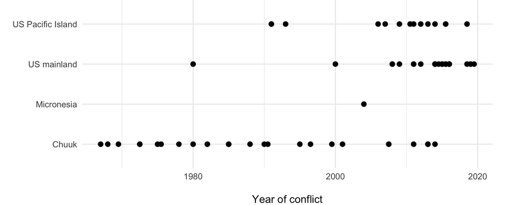

Figure 1: The year and location of each conflict. Each dot is one conflict. Chuuk and US mainland: conflict occurred exclusively in one of those locations. US Pacific Island: conflict occurred at least in part in Guam or Hawaii. Micronesia: conflict occurred exclusively in Micronesia.

## Conflict causes

KLS coded each conflict for one or more causes, and then KLS and EHH aggregated these specific causes into more general categories. See Table 3.

Table 3: Causes of conflicts

| General category | Specific |
| --- | --- |
| activities with friends | play, hang out, substance use, friendships, peer acceptance, texting_social media_gaming, going to friend’s house |
| education | school choice, curriculum choice, skip school, education, academic performance, commute to school |
| family or home tension | competing family alliances, home stress, sibling rivalry, adoption_guardianship, parental absence, take too long to get ready, physical health, parent deception, physical abuse, parents arguing, feel … |
| family responsibilities | chores, childcare, care taking |
| fighting or aggression outside the home | fighting, destroy_property, public argument |
| mateship | mateship, arranged marriage, pregnancy, marriage |
| religion | church, religion |
| resource allocation | resource allocation(bed), resource allocation(goods), resource allocation(money), resource allocation(tv) |
| safety | safety |
| social or cultural norms | cultural norms, social role |
| time away from home or family | staying away from home, moving out, out too late, out too long |
| work | work |

The frequencies of the general causes of conflicts are depicted in Figure 2.

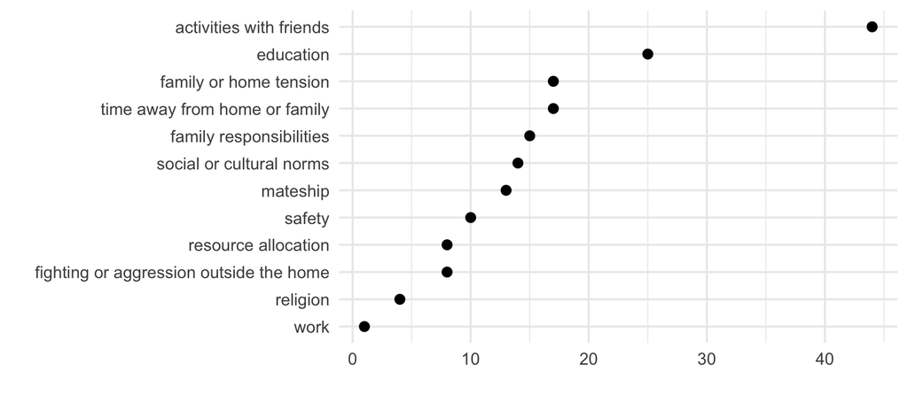

Figure 2: The frequencies of general causes of conflicts. Most conflicts had multiple causes.

## Heatmap of Causes

To obtain an overview of which causes co-occurred, we generated a heatmap in which each conflict (columns) and the general causes involved (rows) were both clustered using hierarchical cluster analysis. See Figure 3. Conflicts often had multiple causes. For example, family responsibilities involved assisting in tasks that benefit family members, such as chores, child care, and care-taking of sick or elderly. Family or home tension involved conflicts at home or within the family that are persistent over time and create a stressful environment including: chronic arguing, competing family alliances, physical abuse, and labor exploitation. The most common source of conflict was activities with friends. One cluster consists of activities with friends, education, family responsibilities, and family or home tension, indicating that these causes tended to co-occur. Another cluster consists of social or cultural norms and mateships that occasionally co-occurred.

The red annotations in the top row indicate a high severity conflict, and clustered along the left side in association with family or home tension.

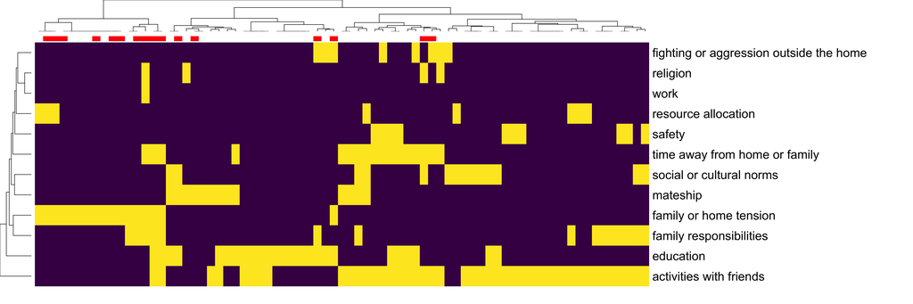

Figure 3: Conflicts and their causes. Each column is one conflict. Each row is the general cause of the conflict. Conflicts often had multiple causes. Yellow: indicates that a conflict involved that cause. Red annotations (top row): indicates a severe conflict. Rows and columns clustered using Ward agglomeration and Euclidean distance.

## Behavioral Strategies

To gain an overview of the relationships among conflict severity, child conflict resolution strategies, and conflict outcomes, we plotted a heatmap of all conflicts vs. all child resolution strategies. See Figure 4.

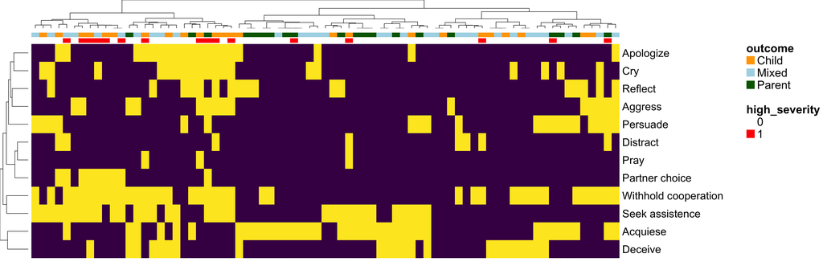

Figure 4: Conflicts and the child’s response. Each column is one conflict. Each row is a child response to the conflict. Children often responded in multiple ways. Red annotations (top row): indicates a severe conflict. Rows and columns clustered using Ward agglomeration and Euclidean distance.

There were two major clusters of conflicts. The smaller cluster (Figure 4, left hand side) comprised mostly severe conflicts with outcomes that were either in the child’s favor or mixed. Conflicts in this cluster tended to involve several strategic responses by the child. In particular, withdrawing cooperation and seeking assistance clustered together in severe conflicts with outcomes that tended to favor the child. Interestingly, children often apologized when the outcome was in their favor.

Conflicts in the larger right hand cluster comprised mostly less severe conflicts that often resolved in the parent’s favor or mixed, and tended to involve fewer strategic responses by the child. These responses were often acquiescence and deception, which clustered together. All of these patterns are consistent with our bargaining model of conflict resolution.

## Exploring predictors of high severity conflicts

A primary aim of the study was to identify factors that distinguished high severity conflicts from other conflicts (for operationalization of “high severity,” see Table 1), and then to determine what strategies children used in high severity vs. other conflicts. Based on the heatmap of conflict causes (Figure 3), it is clear that high severity conflicts were associated with family or home tension. In part, this is because we interpreted physical abuse as evidence for both high severity and for home or family tension. However, there were many cases of home or family tension that were not severe, and many severe conflicts that did not involve home or family tension. Family or home tension included, e.g., competing family alliances, home stress, sibling rivalry, adoption/guardianship, parental absence, physical health, parent deception, physical abuse, parents arguing, and feeling exploited (see Table 3).

### Association of conflict types with severity

Because severity was partially confounded with home or family tension, we fit an elastic net logistic regression model of severity status as a function of all causes *except* home or family tension. This model revealed that activities with friends was a strong negative predictor that a conflict was severe. Positive predictors of severity were spending time away from home or family and conflicts over family responsibilities. See Figure 5.

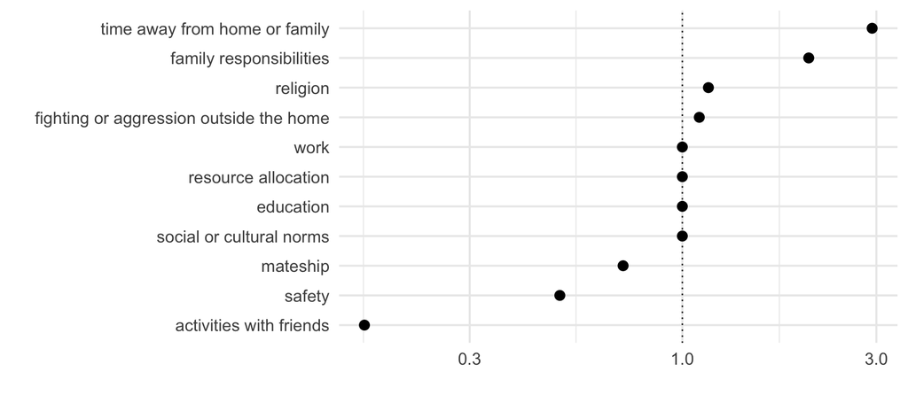

Figure 5: Predictors that a conflict was severe. Coefficients are from an elastic net logistic regression with alpha = 0 and lambda chosen via cross-validation. Values are adjusted odds ratios.

### Association of child strategies with severity

*A priori*, we predicted that withholding cooperation would be a child conflict resolution strategy (see Table 1) that was closely associated with severe conflicts, and indeed it was, with high cost withholding strategies more strongly related than low cost withholding strategies. See Figure 6.

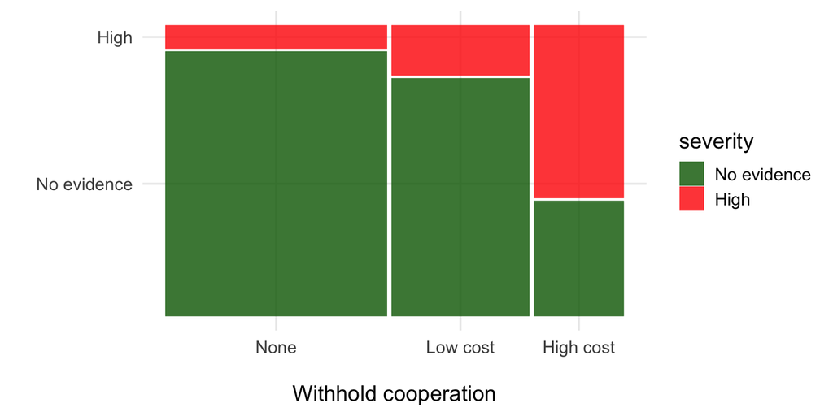

We then fit an exploratory lasso regression of all child strategies as predictors of conflict severity. Partner choice was the largest positive predictor, withholding cooperation was the second largest, and Deception/withhold information was a negative predictor. See Figure 7.

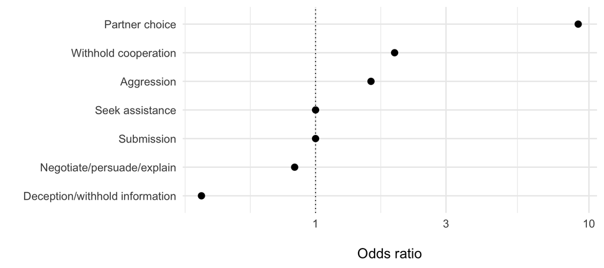

Figure 7: Logistic lasso regression of conflict severity as a function of child strategies. Values are odds ratios.

### Sociodemographic predictors of high severity

To determine the best predictors of conflict severity, we fit logistic regression models of conflict severity as a function of theoretically motivated predictors variables, including age at the time of conflict, sex, number of siblings, duration of conflict, grip strength, and the parent in the conflict (e.g., father or mother). In this exploratory analysis, the model with the lowest AIC score had three predictors – the number of biological siblings, mean age at the time of conflict, and age at interview – and a modest effect size (Tjur’s D = 0.28). Figure 8 depicts this model with unscaled variables and over-plotted with the actual data. Table 4 presents the coefficients from the same model as odds ratios, but with predictors converted to Z-scores. Hence, a one standard deviation increase in the age at the time of conflict increased the odds that the conflict was severe by 2.5, and a one standard deviation increase in the number of biological siblings increased the odds by 3.9.

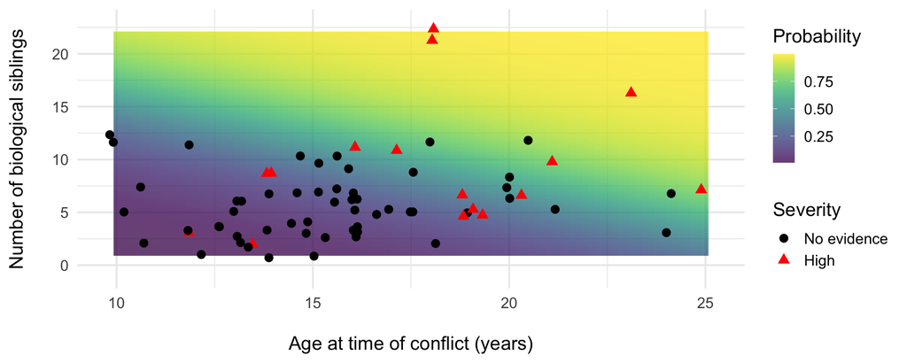

Figure 8: Conflict severity as a function of age at the time of conflict and number of biological siblings (controlling for age at time of interview). Background color represents the predicted probability of a severe conflict from a logistic regression model (see Table 4). Each dot is one conflict, color-coded by it’s actual severity (a small amount of jitter was added to reveal overlapping points).

Table 4: Logistic regression of conflict severity. Predictor variables are Z-scores and coefficients are odds ratios (95% CI).

| Age at interview (Z) | 0.432 (0.155, 1.01) |
| --- | --- |
| Age at conflict (Z) | 2.51 (1.25, 5.84) |
| Number of siblings (Z) | 3.86 (1.65, 12.4) |
| Observations | 73 |
| AIC | 65.92 |
| Tjur’s D | 0.28 |
| Null deviance (df) | 76.8 (72) |
| Residual deviance (df) | 57.9 (69) |
| Chisqr | Chisq (3) = 18.9*** |

## Outcomes

Outcomes were coded as favoring the child, favoring the parent, or favoring both or neither (mixed). We explored factors that were associated with outcomes favoring the child. We used ridge regression to explore which child strategies were associated with outcomes favoring the child. In this analysis we omitted mixed outcomes, only comparing outcomes favoring the child vs. the parent, and we also omitted the “submission” strategy which almost always implied that the outcome favored the parent. See Figure 9.

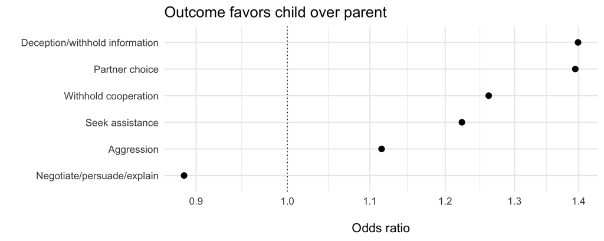

Figure 9: Elasicnet binomial regression coefficients of outcomes favoring the child vs the parent as predicted by the different child strategies (mixed outcomes were omitted from this analysis). Coefficients are odds ratios.

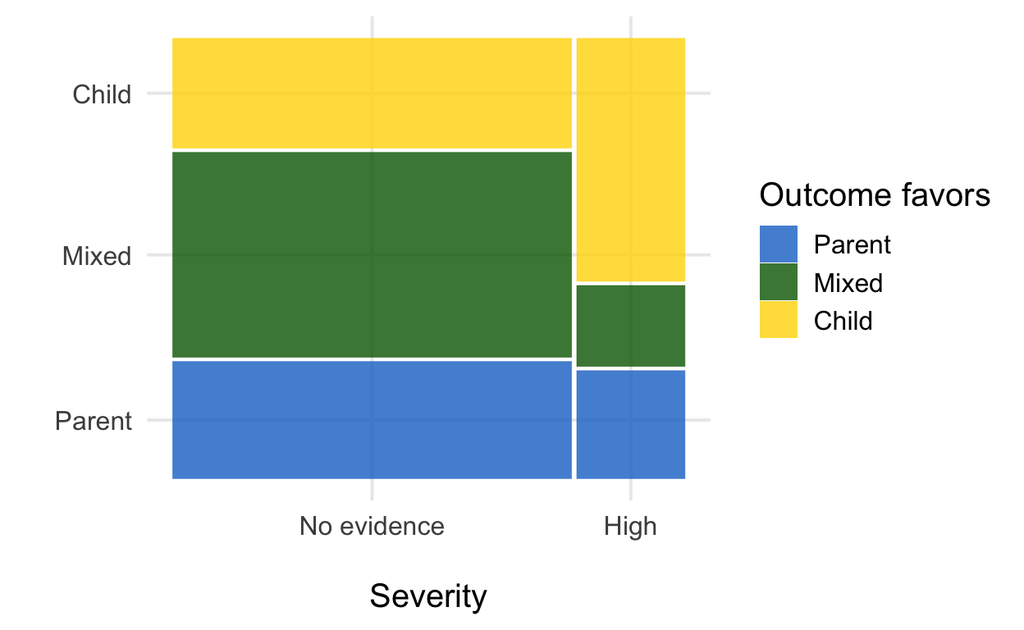

Figure 10: Conflict outcomes vs. conflict severity.

# Discussion

Activities with friends (including cousins and non-kin peers) was the most frequently reported cause of conflict (Figure 2). According to the heatmap of conflict causes (Figure 3), time spent with friends often conflicted with time invested in education and household and family responsibilities. Conflicts over mateships were also common and conflicted with time invested in the family and in education.

This result indicates that conflicts over offspring time and energy allocation were the most common sources of conflict. As early as the age of 5, human offspring can begin contributing to household productivity, and their contributions increase over the course of development. However, socialization into peer groups is also an important aspect of human adolescent development. The prevalence of this source of conflict suggests that offspring likely stand to gain by devoting more time to playing and socialization in peer groups than is in the interests of the parents who might stand to gain more by having offspring invest more time and energy in the household. Assistance from adolescent children in household tasks potentially frees up the parent to spend more time and energy on other offspring or the parent’s own economic or social pursuits.

Conflicts over education, including school choice, curriculum choice, and offspring’s time investment in attending school and doing homework, were also common. Parents expressed anxieties about their offsprings’ abilities to attain status in adulthood, and education is perceived as the primary means of achieving status. Informants report that the high school drop out rate is high in the U.S. and Chuuk, and many parents feel that they must actively push their children to stay in school. When one student was joking around during classes and not doing assignments, a parent lectured the young adolescent saying, “Do you want to be like the people back home [in Chuuk]? They don’t have an education.” Even if students do not choose to drop out, young males, in particular, might be kicked out for fighting. Adolescent females, on the other hand, are more likely to drop out due to pregnancy or marriage. Several young females described the “typical Chuukese girl” as one that gets pregnant and drops out–a stereotype that many girls seek to distance themselves from.

“Conflicts” over education might not be instances of parent-offspring conflict because, rather than desiring children’s greater investment in the family, parents appear to want their children to invest in themselves. Hence, conflicts over education might be better characterized as differences in knowledge or opinions about the value of education vs. other uses of children’s time.

## Behavioral strategies

‘Withholding cooperation’ was the most common child behavioral response to conflict (n=38). Our model of withholding cooperation is rooted in game theoretical models of bargaining, in which withholding cooperation is a credible signal that the agent does not value the current terms of cooperation, as well as models of behavioral withdrawal strategies endemic to Chuukese culture. Withdrawal strategies include physically withdrawing from a conflict, avoidance, breaking rules and agreements, running away, moving away, and, in the extreme, suicidal behavior. Withdrawal places temporary distance between the individual and the other party and is often motivated by a desire to be alone to collect one’s thoughts and emotions. As one participant stated, “I always just go in the bathroom and cry, not sobbing. Just tears come down, just letting everything out and then I just move on.” Withdrawal typically followed an argument or confrontation to which the child would respond by going out for a walk to vent emotions or retreating to their room where they would hide out until falling asleep or growing hungry. Some interviewees discussed withdrawal as a means to hide or escape from the conflict, but in most cases, simply being alone was a key motivator. However, a handful sought the company of others or engaged in an activity to get their minds off their troubles.

Withdrawal strategies ranged from transitory withdrawal and avoidance, which we coded as “low cost,” to running away or moving away, which we coded as “high cost” (we had one case of suicidal ideation, which also involved running away, and was coded as “high cost”). Lowe (2003) described transitory withdrawal to manage negative emotions as a positive behavioral pathway Chon Chuuk young people use, and that was often the case in our data too. Quiet contemplation led some to feel remorse, and there was clear evidence in some cases that temporary withdrawal fostered motivations to reconcile. However, anything more than brief withdrawal can incur costs on both offspring and parents as is predicted by the signaling model of withholding cooperation.

Some adolescents withheld cooperation by reducing their investment in their education. Signs of a lack of commitment to school are a major source of anxiety for Chon Chuuk parents who have worked hard to instill in their children the value of education in the hopes that they will graduate and be able to secure an adequate income in adulthood. One student who faced persistent conflicts between family members described emotions and behaviors associated with withdrawal surfacing while in school. “If I’m sad about something, I do get a little upset in school and don’t want to do work. I’ll be thinking about the [conflict] and just want to lay down and listen to music.” Two interviewees who were in high school at the time of their respective conflicts expressed deep disappointment in decisions parents had made about their education. Both participants dropped out of school despite nearing completion, in part, due to discontent, which led to apathy and ultimately giving up.

Offspring behaviors categorized as avoidance were associated with resentment towards parents. Avoidance behaviors could emerge briefly, intermittently, or last over the course of years and largely concerned minimizing communication by ignoring parents, not talking to them, and generally making oneself unavailable, even though the cooperative relationship persisted. One adolescent stated, “I try to avoid them but then [they] tell me to do something and you can’t say ‘no’ to that. I just act like they’re not there.” Several participants indicated tit-for-tat avoidance exchanges: when one party began avoiding the other, the other party returned in kind. One individual recounted mutual avoidance with a parent that lasted for several years because of the individual’s choice of marriage partner. Both the parent and the child reduced contact but were never estranged. Mutual avoidance often ended in spoken or unspoken reconciliation when either one party conceded or when the child entered a new phase in life such as marriage or the birth of a child. Some degree of family avoidance behaviors, however, are normal in Chuukese culture. Young men are expected to follow cross-sex sibling avoidance norms after puberty, which is one reason brothers spend more time away from home than their sisters. None of the behaviors we coded as “avoidance” involved these cultural norms.

The most common response to long standing troubles in the home was running away, which in several instances entailed placing oneself at risk of harm. Running away, staying with other family members for an extended time, or moving away from parents tends to signify that the parent-child cooperative relationship is in jeopardy. A common reason for young men to run away or move away from their family was substance use and activities with male peers. The centrality of alcohol in young male status seeking is a common theme in the ethnographic literature (M. Marshall 1979; Hezel 1989, 1987). The disinhibitory effects of intoxication make young males more courageous and able to engage in risky undertakings to prove their bravery (pwora). Chon Chuuk males are notorious for getting into drunken brawls with peers. Many male participants stated that alcohol gave them ‘bad ideas’ or caused them to ‘not think right.’ But drinking parties also presented opportunities for male bonding and social learning. One man stated that drinking socially was “a learning process for our culture, hanging out with older friends who would talk about culture and about being a Chuukese person in the community.” They would acquire information from their older peers about how to be respectful, how to get with women without disrespecting her family, and how to meet girls in secret. Several participants said that although they were a bystander to many fights, they did not participate in fights themselves, and that they were motivated to drink socially to strengthen relational ties with peers.

Seeking assistance was another common strategy (n=32), one that co-occurred with withholding cooperation about half of the time. Siblings, extended kin, and parents (if conflict only between one parent) play important roles in resolving conflicts between parents and offspring. Assistance consisted of providing advice, comfort, or a place to stay; kin members were further often involved in direct intervention, playing the role of a mediator. Maternal kin were more often sought out for aid perhaps because families often live closer to maternal kin in this matrilineal society, but paternal kin were also a source of assistance. After one young woman ran away for 2 nights, she was discovered by an aunt who walked back with her to her parents’ house the following day. “If parents see that auntie or uncle brought her back,” she said, “then parents have to accept her.” Extended kin, in the most severe cases of parent-child conflict, even rescued nieces, nephews, and cousins from abusive parental relationships.

Aggression was the least common strategy (n=15) and included heated arguing, yelling, threatening physical aggression, or using physical aggression. From a game theoretical perspective, qualities about the individual relative to their competitor, such as formidability and the ability to form coalitions, and resource holding potential should predict the use of aggression. (We would predict that those who used aggression would tend to be male sex, older, have greater upper body strength, and have fewer siblings.) Females were just as likely to use an aggressive strategy as males, but most cases involved heated arguing or yelling. Only 2 participants threatened or used physical aggression–one male and one female. In both instances, they physically aggressed against the same-sex parent in the context of a high severity conflict. Both cases resulted in an outcome favoring the child. Many adult Chon Chuuk perceive that children raised in the U.S. are more aggressive. One participant stated, “The generation who was born here, they don’t have the same values of being humble… Children will talk back and that is something we were raised not to do, especially with parents and aunties and uncles.” Although aggressiveness was slightly more common among U.S. adolescents than those in Chuuk, the data are insufficient to determine if this is a real trend.

## Outcomes

Outcomes were relatively evenly distributed among those favoring the parent, those favoring the child, and those favoring both/neither. An exploratory logistic ridge regression found that deception/withholding information and partner choice were the largest positive predictors of outcomes favoring the child over the parent, and negotiate/persuade/explain was a negative predictor of the outcome favoring the child. See Figure 9.

## Predictors of High Severity Conflicts

A major goal of the study was to identify factors that distinguished severe conflicts from other conflicts, under the assumption that understanding severe (but non-suicidal) conflicts would illuminate conflicts that lead to suicide. Severe conflicts were operationalized as those involving a severe behavior on the part of the parent or household member, e.g., a parent physically threatening a child, exposure to violence at home, a parent threatening to eliminate or drastically reduce investment (such kicking out of home or family), parental absence, or a parent causing a child severe psychological distress or uncertainty.

The heatmap (Figure 3, left-hand cluster) revealed that most severe conflicts involved family or home tension, which we had operationalized as conflicts involving competing family alliances, home stress, adoption/guardianship, parental absence, physical abuse, and feeling exploited. Thus, some of the association of severe conflicts with home or family tension is a consequence of their similar operationalizations. In principle, though, severe conflicts could have involved conflicts over school, friends, or romantic partners, but they mostly did not. This finding coincides with the ethnographic literature on the nature of conflicts that lead to suicide–that they generally follow years of family turmoil (Hezel 1984). Other cases of high severity conflict concerned offspring status-building activities and in one case a forced marriage.

The lasso regression (Figure 5), which explored predictors of high severity conflicts other than home or family tension (which was omitted from this analysis because this variable overlapped with our operationalization of severity), revealed that spending time away from the home or family and evading family responsibilities were positive predictors of high severity, whereas activities with friends was a strong negative predictor of severity. Because spending time with friends would seem to entail spending time away from home or family, we investigated why these variables had opposite associations with severity. Looking at the heatmap (Figure 3), many conflicts involving activities with friends did not entail time away from home or evading family responsibilities, and these conflicts were not severe – sometimes these were “conflicts” over education, and therefore probably not instances of genuine POC. In contrast, activities with friends that *did* entail time away from home or evading family responsibilities had a higher likelihood of being severe.

According to our logistic regression analysis (Figure 8), older age and number of biological siblings increased the odds that the conflict was of high severity. Concerning later adolescence, Lowe (2003) observed that, “…the stakes present in the parent–child relationship are much higher during this period of the life course. Young people depend on their parents for most of their needs and parents depend on them for the daily management of the household [p. 199].” Yet, older adolescents are also exploring new roles and developing new identities within a larger community that includes peers. The amount of time and energy older adolescents and young adults invest in status-building activities can determine their economic and political roles within the community, who they end up marrying, and the timing of marriage and reproduction. Ongoing conflicts might also escalate when adolescents reach older ages, because they have greater autonomy to withhold cooperation from parents and cooperate with others such as extended kin. Extended kin might be more willing to invest, because older adolescents and younger adults are less costly than younger children and are in a better position to reciprocate. Alternatively, this finding might also be a byproduct of the developmental stage under investigation, and the types of conflicts participants are willing to discuss.

The relationship between number of biological siblings and increased odds that the conflict was severe might suggest a conflict over alloparenting: as older children pursue their own status and mating opportunities, which benefits them, they have less time to care for younger siblings, which increases the burden on their parents. Alternatively, as POC theory predicts, parents will attempt to spread investment across all offspring to enhance their own reproductive success at the expense of individual offspring. (This pattern of investment will also hold true in extended kin social settings where individuals share both reproductive interests and conflicts.) When parents have a greater number of offspring, individual offspring might be at heightened risk of suffering abuse, exploitation, or lack of investment. The relationship between number of biological siblings and risk of experiencing severe conflicts with parents is likely mediated by other factors such as resource availability.

We did not find that degree of relatedness predicted severity of conflict or whether or not the outcome ended in the child’s favor contra to previous studies that have shown that living with a non-biological parent increases the risk of maltreatment and homicide in children (Daly and Wilson 1988; Daly, Wilson, et al. 1988; Wilson and Daly 1987; but see also Temrin, Buchmayer, and Enquist 2000). However, adoptions almost always occur within families and most typically between siblings. Children are usually given in adoption based on the needs of the adopting parent. Adopted children in most cases maintain a relationship with their biological parents, and these kinship networks engage in regular reciprocal exchanges of material resources.

# Limitations

The present study is an exploratory analysis, and the findings presented here are intended to point to avenues for future research using larger representative data sets in Chuuk and elsewhere. A key limitation is that the interviews were retrospective, and participants might have forgotten or misremembered important details and events. Memories of events and the order of their sequence can and do change over time. Participants could discuss any conflict that they wanted, and there was in all likelihood some bias in the types of conflicts participants were willing to disclose. All interviews were also conducted in English, which for most Chon Chuuk is their second language.

# Conclusions

Syme, Garfield, and Hagen (2016) found that patterns of suicide in the ethnographic record were well-explained by the bargaining model. According to game theoretic models, withdrawal represents a bargaining strategy that signals the actors’ low valuations of the cooperative endeavor. This strategy is resorted to when aggressive strategies, i.e., threatening to impose costs on others at no or low cost to the self, are not available and victims are powerless. Suicidal behaviors would be the most severe end of a spectrum of behaviors involving the withholding of cooperation. Chon Chuuk have a cultural model of responses to conflict, termed amwunumwun, that corresponds closely to withholding of cooperation, and that includes suicidal behavior as its most extreme manifestation.

Most of our results regarding severe conflicts also supports the bargaining model, suggesting that studying these much more common situations could provide important insights into the rare but potentially deadly situations involving suicidal behavior. Specifically, severe conflicts mostly involved family or home tensions surrounding levels of investment in the family, and children respond by withholding of cooperation, seeking assistance from others, or moving in with relatives or a mate (partner choice). Severe conflicts often occurred among older children with many siblings, suggesting that these involved conflicts over whether investments in the family should benefit the parents or the child.

Supporting the correspondence of the severe non-suicidal conflicts studied here with suicidal ones, reports of severe psychological distress in this study were only associated with cases in which the conflict was classified as high severity and the child acquiesced or the parent ignored the child’s bargaining attempts. In the few cases where powerless offspring acquiesced in high severity conflicts, they reported depression, panic, and seeking mental health resources. Suicidal behavior might be used when children in severe conflicts with parents have exhausted all other strategies without obtaining any concessions.

# References

Apostolou, Menelaos. 2007. “Sexual Selection Under Parental Choice: The Role of Parents in the Evolution of Human Mating.” *Evolution and Human Behavior* 28 (6): 403–9.

———. 2015. “Parent–Offspring Conflict over Mating: Domains of Agreement and Disagreement.” *Evolutionary Psychology* 13 (3): 1474704915604561.

Archer, John, and VanLal Thanzami. 2007. “The Relation Between Physical Aggression, Size and Strength, Among a Sample of Young Indian Men.” *Personality and Individual Differences* 43 (3): 627–33.

Betzig, Laura L. 1988. “Adoption by Rank on Ifaluk.” *American Anthropologist* 90 (1): 111–19.

Bird, Douglas W, and Rebecca Bliege Bird. 2017. “Martu Children’s Hunting Strategies in the Western Desert, Australia.” In *Hunter-Gatherer Childhoods*, 129–46. Routledge.

Bogin, Barry, Carlos Varea, Michael Hermanussen, and Christiane Scheffler. 2018. “Human Life Course Biology: A Centennial Perspective of Scholarship on the Human Pattern of Physical Growth and Its Place in Human Biocultural Evolution.” *American Journal of Physical Anthropology*.

Bossan, Benjamin, Peter Hammerstein, and Arnulf Koehncke. 2013. “We Were All Young Once: An Intragenomic Perspective on Parent–Offspring Conflict.” *Proceedings of the Royal Society B: Biological Sciences* 280 (1754): 20122637.

Bowers, E Keith, Jonathan B Jenkins, Alexander J Mueller, Kelly D Miller, Charles F Thompson, and Scott K Sakaluk. 2019. “Condition-Dependent Begging Elicits Increased Parental Investment in a Wild Bird Population.” *The American Naturalist* 193 (5): 725–37.

Breeding, Cooperative. 2009. “Does It Take a Family to Raise a Child?” *Substitute Parents: Biological and Social Perspective on Alloparenting Across Human Societies* 3: 77.

Budden, Amber E, and Jonathan Wright. 2001. “Falling on Deaf Ears: The Adaptive Significance of Begging in the Absence of a Parent.” *Behavioral Ecology and Sociobiology* 49 (6): 474–81.

Buunk, Abraham P, Justin H Park, and Shelli L Dubbs. 2008. “Parent–Offspring Conflict in Mate Preferences.” *Review of General Psychology* 12 (1): 47–62.

Buunk, Abraham P, and Alejandro Castro Solano. 2010. “Conflicting Preferences of Parents and Offspring over Criteria for a Mate: A Study in Argentina.” *Journal of Family Psychology* 24 (4): 391.

Caro, Shana M, Ashleigh S Griffin, Camilla A Hinde, and Stuart A West. 2016. “Unpredictable Environments Lead to the Evolution of Parental Neglect in Birds.” *Nature Communications* 7: 10985.

Caughey, John L. 1977. *Fa’a’nakkar Cultural Values in a Micronesian Society*. University of Pennsylvania.

Chagnon, Napoleon A. 1979. “Mate Competition, Favoring Close Kin, and Village Fissioning Among the Yanomamo Indians.” *Evolutionary Biology and Human Social Behavior*, 86–132.

Chagnon, Napoleon A, Robert F Lynch, Mary K Shenk, Raymond Hames, and Mark V Flinn. 2017. “Cross-Cousin Marriage Among the Yanomamö Shows Evidence of Parent–Offspring Conflict and Mate Competition Between Brothers.” *Proceedings of the National Academy of Sciences* 114 (13): E2590–2607.

Daly, Martin, and Margo Wilson. 1988. “Evolutionary Social Psychology and Family Homicide.” *Science* 242 (4878): 519–24.

Daly, Martin, Margo Wilson, et al. 1988. “The Darwinian Psychology of Discriminative Parental Solicitude.” In *Nebraska Symposium on Motivation*, 35:91–144.

Dubbs, Shelli L, and Abraham P Buunk. 2010. “Parents Just Don’t Understand: Parent-Offspring Conflict over Mate Choice.” *Evolutionary Psychology* 8 (4): 147470491000800420.

Dubbs, Shelli L, Abraham P Buunk, and Hirokazu Taniguchi. 2013. “Parent-Offspring Conflict in j Apan and Parental Influence Across Six Cultures.” *Japanese Psychological Research* 55 (3): 241–53.

Ember, Carol R, and Melvin Ember. 2005. “Explaining Corporal Punishment of Children: A Cross-Cultural Study.” *American Anthropologist* 107 (4): 609–19.

Fischer, Ann. 1950. *The Role of the Trukese Mother and Its Effect on Child Training*. Pacific Science Board, National Research Council.

———. 1963. “Reproduction in Truk.” *Ethnology* 2 (4): 526–40.

Gladwin, Thomas, and Seymour B Sarason. 1953. “Truk: Man in Paradise.”

Godfray, H Charles J. 1991. “Signalling of Need by Offspring to Their Parents.” *Nature* 352 (6333): 328.

Godfray, HCJ. 1995. “Signaling of Need Between Parents and Young: Parent-Offspring Conflict and Sibling Rivalry.” *The American Naturalist* 146 (1): 1–24.

Goodenough, Ruth G. 1970. “Adoption on Romonum, Truk.” *Adoption in Eastern Oceania*. Honolulu, Hawaii: University of Hawaii Press.

Goodenough, Ward H. 1949. “PREMARITAL FREEDOM ON TRUK: THEORY AND PRACTICE 1.” *American Anthropologist* 51 (4): 615–20.

———. 1974. “Changing Social Organization on Romonum, Truk, 1947-1965.” *Social Organization and the Applications of Anthropology: Essays in Honor of Lauriston Sharp, Edited by Robert J. Smith*, 62–93.

Goodenough, Ward Hunt. 1951. *Property, Kin, and Community on Truk*. Vol. 46. Department of Anthropology, Yale University New Haven, CN.

Goodenough, Ward Hunt, and Ian A Skoggard. 1999. “Culture Summary: Chuuk.” *eHRAF World Cultures*. HRAF.

Hagen, Edward H. 2003. “The Bargaining Model of Depression.” *Genetic and Cultural Evolution of Cooperation*, 95–123.

Hawkes, Kristen, James F O’Connell, NG Blurton Jones, Helen Alvarez, and Eric L Charnov. 1998. “Grandmothering, Menopause, and the Evolution of Human Life Histories.” *Proceedings of the National Academy of Sciences* 95 (3): 1336–39.

Helfrecht, Courtney, and Courtney L Meehan. 2016. “Sibling Effects on Nutritional Status: Intersections of Cooperation and Competition Across Development.” *American Journal of Human Biology* 28 (2): 159–70.

Hess, Nicole, Courtney Helfrecht, Edward Hagen, Aaron Sell, and Barry Hewlett. 2010. “Interpersonal Aggression Among Aka Hunter-Gatherers of the Central African Republic.” *Human Nature* 21 (3): 330–54.

Hezel, Francis X. 1984. “Cultural Patterns in Trukese Suicide.” *Ethnology* 23 (3): 193–206.

———. 1987. “In Search of the Social Roots of Mental Pathology in Micronesia.” *Contemporary Issues in Mental Research in the Pacific Islands*, 12–31.

———. 1989. “Suicide and the Micronesian Family.” *The Contemporary Pacific*, 43–74.

Hezel, Francis X, and J Dobbin. 1995. “Possession and Trance in Chuuk.” *Isla* 3 (1): 73–104.

Hezel, Francis X, and Michael Levin. 2012. “Survey of Federated States of Micronesia Migrants in the United States Including Guam and the Commonwealth of Northern Mariana Islands (CNMI).”

Hezel, Francis X, and Michael J Levin. 1996. “New Trends in Micronesian Migration: FSM Migration to Guam and the Marianas, 1990-1993.” *Pacific Studies* 19 (1): 91.

Kaplan, Hillard, Kim Hill, Jane Lancaster, and A Magdalena Hurtado. 2000. “A Theory of Human Life History Evolution: Diet, Intelligence, and Longevity.” *Evolutionary Anthropology: Issues, News, and Reviews: Issues, News, and Reviews* 9 (4): 156–85.

Kennan, John, and Robert Wilson. 1993. “Bargaining with Private Information.” *Journal of Economic Literature* 31 (1): 45–104.

Kilner, Rebecca, and Rufus A Johnstone. 1997. “Begging the Question: Are Offspring Solicitation Behaviours Signals of Need?” *Trends in Ecology & Evolution* 12 (1): 11–15.

Kramer, Karen L. 2005. “Children’s Help and the Pace of Reproduction: Cooperative Breeding in Humans.” *Evolutionary Anthropology: Issues, News, and Reviews: Issues, News, and Reviews* 14 (6): 224–37.

LeVine, Robert A, Suzanne Dixon, Sarah LeVine, Constance H Keefer, Amy Richman, P Herbert Leiderman, and T Berry Brazelton. 1996. *Child Care and Culture: Lessons from Africa*. Cambridge university press.

Levinson, David. 1981. “Physical Punishment of Children and Wifebeating in Cross-Cultural Perspective.” *Child Abuse & Neglect* 5 (2): 193–95.

Lindsay Lee, Max Roser, and Esteban Ortiz-Ospina. 2019. “Suicide.” *Our World in Data*.

Lowe, Edward D. 2002. “A Widow, a Child, and Two Lineages: Exploring Kinship and Attachment in Chuuk.” *American Anthropologist* 104 (1): 123–37.

———. 2003. “Identity, Activity, and the Well-Being of Adolescents and Youths: Lessons from Young People in a Micronesian Society.” *Culture, Medicine and Psychiatry* 27 (2): 187–219.

Macfarlan, Shane J, Pamela I Erickson, James Yost, Jhanira Regalado, Lilia Jaramillo, and Stephen Beckerman. 2018. “Bands of Brothers and in-Laws: Waorani Warfare, Marriage and Alliance Formation.” *Proceedings of the Royal Society B* 285 (1890): 20181859.

Marshall, Leslie B, and Mac Marshall. 1980. “Infant Feeding and Infant Illness in a Micronesian Village.” *Social Science & Medicine. Part B: Medical Anthropology* 14 (1): 33–38.

Marshall, Mac. 1976. “Solidarity or Sterility? Adoption and Fosterage on Namoluk Atoll.” *Transactions in Kinship: Adoption and Fosterage in Oceania*, 28–50.

———. 1979. *Weekend Warriors: Alcohol in a Micronesian Culture*. McGraw-Hill Humanities Social.

———. 1981. “Sibling Sets as Building Blocks in Greater Trukese Society.” *Siblingship in Oceania: Studies in the Meaning of Kin Relations*, 201–24.

———. 1983. “Sibling Sets as Building Blocks in Greater Trukese Society.” *Siblingship in Oceania: Studies in the Meaning of Kin Relations*, 201–24.

Moreno-Rueda, Gregorio. 2010. “An Immunological Cost of Begging in House Sparrow Nestlings.” *Proceedings of the Royal Society B: Biological Sciences* 277 (1690): 2083–88.

Moreno-Rueda, Gregorio, and T Redondo. 2011. “Begging at High Level Simultaneously Impairs Growth and Immune Response in Southern Shrike (Lanius Meridionalis) Nestlings.” *Journal of Evolutionary Biology* 24 (5): 1091–98.

Parker, Geoffrey A. 1974. “Assessment Strategy and the Evolution of Fighting Behaviour.” *Journal of Theoretical Biology* 47 (1): 223–43.

Rauchholz, Manuel. 2012. “Discourses on Chuukese Customary Adoption, Migration, and the Laws of State (s).” *Pacific Studies* 35 (1): 119–43.

Redondo, Tomas, David Ochoa, Gregorio Moreno-Rueda, and Jaime Potti. 2016. “Pied Flycatcher Nestlings Incur Immunological but Not Growth Begging Costs.” *Behavioral Ecology* 27 (5): 1376–85.

Rubinstein, Donald H. 1987. “Cultural Patterns and Contagion: Epidemic Suicide Among Micronesian Youth.” *Contemporary Issues in Mental Health Research in the Pacific Islands*, 127–48.

———. 1992. “Suicide in Micronesia and Samoa: A Critique of Explanations.” *Pacific Studies* 15 (1): 51–75.

———. 1995. “Love and Suffering: Adolescent Socialization and Suicide in Micronesia.” *The Contemporary Pacific*, 21–53.

Sear, Rebecca, and Ruth Mace. 2008. “Who Keeps Children Alive? A Review of the Effects of Kin on Child Survival.” *Evolution and Human Behavior* 29 (1): 1–18.

Sear, Rebecca, Ruth Mace, and Ian A McGregor. 2000. “Maternal Grandmothers Improve Nutritional Status and Survival of Children in Rural Gambia.” *Proceedings of the Royal Society of London. Series B: Biological Sciences* 267 (1453): 1641–47.

Sear, Rebecca, Fiona Steele, Ian A McGregor, and Ruth Mace. 2002. “The Effects of Kin on Child Mortality in Rural Gambia.” *Demography* 39 (1): 43–63.

Sell, Aaron. 2005. *Regulating Welfare Tradeoff Ratios: Three Tests of an Evolutionary-Computational Model of Human Anger*. University of California, Santa Barbara.

Sell, Aaron, Liana SE Hone, and Nicholas Pound. 2012. “The Importance of Physical Strength to Human Males.” *Human Nature* 23 (1): 30–44.

Sell, Aaron, John Tooby, and Leda Cosmides. 2009. “Formidability and the Logic of Human Anger.” *Proceedings of the National Academy of Sciences* 106 (35): 15073–78.

Smetana, Judith G, and Myriam Villalobos. 2009. “Social Cognitive Development in Adolescence.” *Handbook of Adolescent Psychology* 1.

Smiseth, Per T, Jonathan Wright, and Mathias Kölliker. 2008. “Parent–Offspring Conflict and Co-Adaptation: Behavioural Ecology Meets Quantitative Genetics.” *Proceedings of the Royal Society B: Biological Sciences* 275 (1645): 1823–30.

Smith, John Maynard, and Geoffrey A Parker. 1976. “The Logic of Asymmetric Contests.” *Animal Behaviour* 24 (1): 159–75.

Smith, Sarah Ann. 2014. “The Reproductive Lives of Chuukese Women: Transnationalism in Guam and Chuuk.”

Soler, Manuel, Francisco Ruiz-Raya, Laura G Carra, Eloy Medina-Molina, Juan Diego Ibáñez-Álamo, and David Martı́n-Gálvez. 2014. “A Long-Term Experimental Study Demonstrates the Costs of Begging That Were Not Found over the Short Term.” *PloS One* 9 (11): e111929.

Sosis, Richard, Sharon Feldstein, and Kim Hill. 1998. “Bargaining Theory and Cooperative Fishing Participation on Ifaluk Atoll.” *Human Nature* 9 (2): 163–203.

Spence, Michael. 1973. “Job Market Signaling.” *The Quarterly Journal of Economics* 87 (3): 355–74.

Spencer, Mary L. 2012. “Paths of Central Caroline Island Children During Migration and Times of Rapid Change.” *Pacific Asia Inquiry* 3 (1): 7–29.

Stieglitz, Jonathan, Michael Gurven, Hillard Kaplan, and Jeffrey Winking. 2012. “Infidelity, Jealousy, and Wife Abuse Among Tsimane Forager–Farmers: Testing Evolutionary Hypotheses of Marital Conflict.” *Evolution and Human Behavior* 33 (5): 438–48.

Stieglitz, Jonathan, Hillard Kaplan, Michael Gurven, Jeffrey Winking, and Basilio Vie Tayo. 2011. “Spousal Violence and Paternal Disinvestment Among Tsimane’forager-Horticulturalists.” *American Journal of Human Biology* 23 (4): 445–57.

Syme, Kristen L., Zachary H. Garfield, and Edward H. Hagen. 2016. “Testing the Bargaining Vs. Inclusive Fitness Models of Suicidal Behavior Against the Ethnographic Record.” *Evolution and Human Behavior* 37 (3): 179–92. https://doi.org/10.1016/j.evolhumbehav.2015.10.005.

Syme, Kristen L., and Edward H Hagen. 2019. “When Saying ‘Sorry’ Isn’t Enough: Is Some Suicidal Behavior a Costly Signal of Apology?” *Human Nature* 30 (1): 117–41.

Temrin, Hans, Susanne Buchmayer, and Magnus Enquist. 2000. “Step–Parents and Infanticide: New Data Contradict Evolutionary Predictions.” *Proceedings of the Royal Society of London. Series B: Biological Sciences* 267 (1446): 943–45.

Trivers, Robert L. 1974. “Parent-Offspring Conflict.” *Integrative and Comparative Biology* 14 (1): 249–64.

Tucker, Bram, and Alyson G Young. 2017. “Growing up Mikea: Children’s Time Allocation and Tuber Foraging in Southwestern Madagascar.” In *Hunter-Gatherer Childhoods*, 147–71. Routledge.

Turke, Paul W. 1988. “Helpers at the Nest: Childcare Networks on Ifaluk.” *Human Reproductive Behavior: A Darwinian Perspective*, 173–88.

Van den Berg, Pieter, Tim W Fawcett, Abraham P Buunk, and Franz J Weissing. 2013. “The Evolution of Parent–Offspring Conflict over Mate Choice.” *Evolution and Human Behavior* 34 (6): 405–11.

Weisner, Thomas S. 1987. “Socialization for Parenthood in Sibling Caretaking Societies.” *Parenting Across the Life Span: Biosocial Dimensions*, 237–70.

Weisner, Thomas S, Ronald Gallimore, Margaret K Bacon, Herbert Barry III, Colin Bell, Sylvia Caiuby Novaes, Carolyn Pope Edwards, et al. 1977. “My Brother’s Keeper: Child and Sibling Caretaking [and Comments and Reply].” *Current Anthropology* 18 (2): 169–90.

Weisner, Thomas S, and Edward D Lowe. 2005. “Globalization, Childhood, and Psychological Anthropology.” *A Companion to Psychological Anthropology*, 315.

Wilson, Margo, and Martin Daly. 1987. “The Risk of Maltreatment of Children Living with Stepparents.” *Child Abuse and Neglect: Biosocial Dimensions*.

Yurgelun-Todd, Deborah. 2007. “Emotional and Cognitive Changes During Adolescence.” *Current Opinion in Neurobiology* 17 (2): 251–57.

Zahavi, Amotz. 1975. “Mate Selection—a Selection for a Handicap.” *Journal of Theoretical Biology* 53 (1): 205–14.

———. 1977. “Reliability in Communication Systems and the Evolution of Altruism.” In *Evolutionary Ecology*, 253–59. Springer.

Zukow-Goldring, Patricia. 2002. “Sibling Caregiving.” *Handbook of Parenting* 3: 253–86.